# General Social Survey

Erika Amado

7 October 2019

# 1 Introduction Question 1

This data is from the 2018 General Social Survey. The first question is this: is opinion on the death penalty (CAPPUN) independent of gun ownership (OWNGUN)?

## 1.1 Methods

Both variables in this analysis are categorical; hence we use bar graphs and tables to summarize the data, and a cross-tabulation for a numerical summary. A Chi-squared test will be used for inference.

$H_0$ : There is no relationship between gun ownership and whether one is in favor of capital punishment.

$H_A$ : There is a relationship between gun ownership and whether one is in favor of capital punishment.

## 1.2 Results

### 1.2.1 Descriptive Results

#### 1.2.1.1 Graphical Descriptive Results

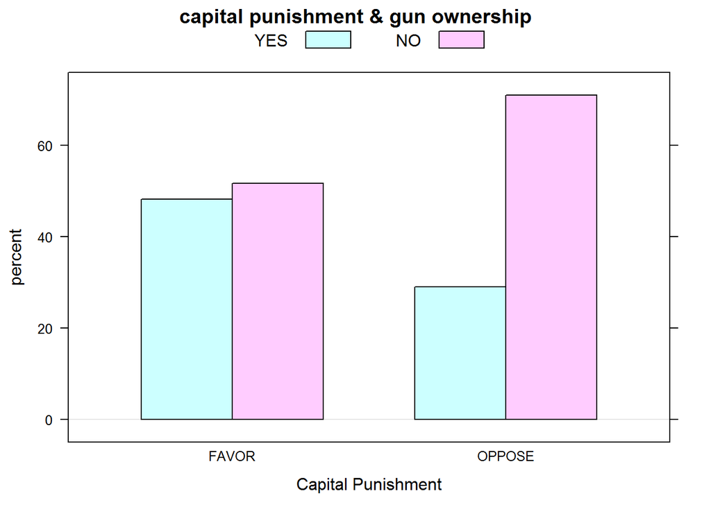

This barchart shows those in favor or oppose to capital punishment and whether they are gun owners or not. The bar chart indicates there is a difference between gun ownership and capital punishment. People who oppose capital punishment tend to not own guns and those who favor capital punishment is about 50/50.

#### 1.2.1.2 Numerical Descriptive Results

```
##         OWNGUN
## CAPPUN      YES     NO  Total
##   FAVOR   48.28  51.72 100.00
##   OPPOSE  29.03  70.97 100.00
```

### 1.2.2 Inferential Results

```
## Pearson's Chi-squared test with Yates' continuity correction
##
## Observed Counts:
##         OWNGUN
## CAPPUN   YES NO
##   FAVOR   56 60
##   OPPOSE  18 44
##
## Counts Expected by Null:
##         OWNGUN
## CAPPUN     YES    NO
##   FAVOR  48.22 67.78
##   OPPOSE 25.78 36.22
##
## Contributions to the chi-square statistic:
##         OWNGUN
## CAPPUN    YES   NO
##   FAVOR  1.25 0.89
##   OPPOSE 2.35 1.67
##
##
## Chi-Square Statistic = 5.3932
## Degrees of Freedom of the table = 1
## P-Value = 0.0202
```

The p-value for the Chisq test is 0.02 < 0.05 so we reject the null hypothesis and conclude we have evidence to support the contention that gun ownership and whether one favors capital punishment are related.

# 2 Introduction Question 2

Now answer Is belief in the bigbang theory (BIGBANG) independent of belief in the afterlife (POSTLIFE)

## 2.1 Methods

Both variables in this analysis are categorical; hence we use bar graphs and tables to summarize the data, and a chi-squared test for inference.

$H_0$ : There is no relationship between people who belive in the big bang theory and the afterlife.

$H_A$ : There is a relationship between people who believe in the big bang theory and the afterlife..

## 2.2 Results

### 2.2.1 Descriptive Results

#### 2.2.1.1 Graphical Descriptive Results

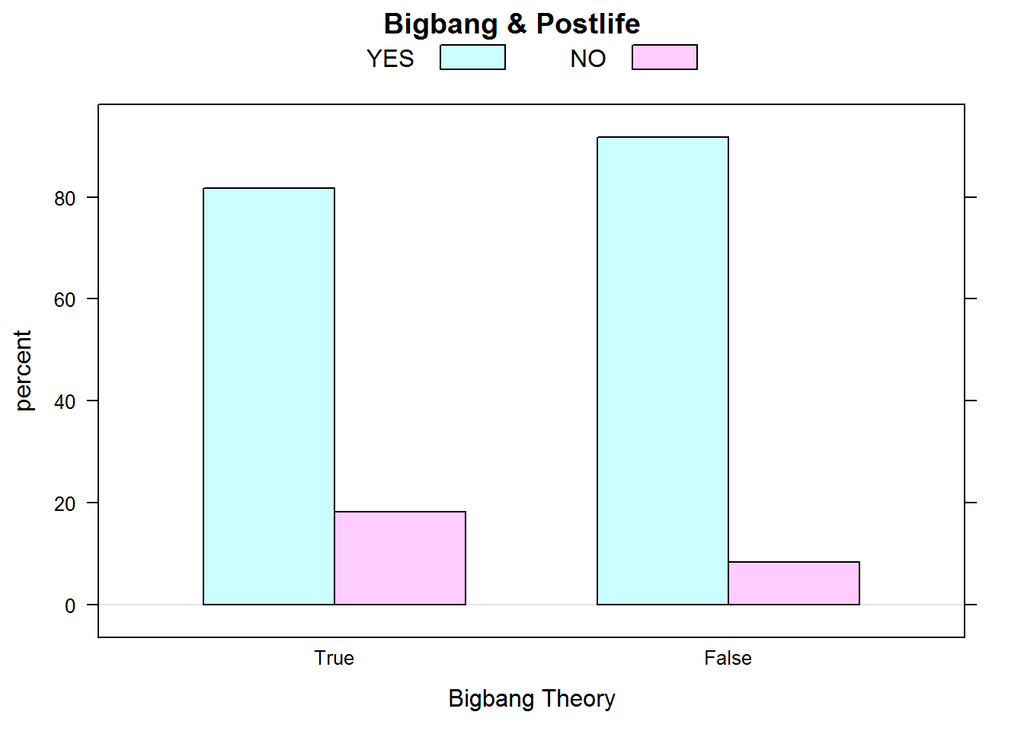

This graph shows us that people who believe in the afterlife are shown in blue which is about the same for both sides who do and do not believe in the bigbang theory. People who do not believe in the afterlife, shown in pink, are a much smaller percenatge compared to those who believe in the afterlife regardless of if they do or do not believe in the bigbang theory. This shows us that the two are unrelated.

#### 2.2.1.2 Numerical Descriptive Results

```
##        POSTLIFE
## BIGBANG    YES     NO  Total
##   True   81.71  18.29 100.00
##   False  91.67   8.33 100.00
```

### 2.2.2 Inferential Results

```
## Pearson's Chi-squared test with Yates' continuity correction
##
## Observed Counts:
##        POSTLIFE
## BIGBANG YES NO
##   True   67 15
##   False  88  8
##
## Counts Expected by Null:
##        POSTLIFE
## BIGBANG  YES   NO
##   True  71.4 10.6
##   False 83.6 12.4
##
## Contributions to the chi-square statistic:
##        POSTLIFE
## BIGBANG  YES   NO
##   True  0.27 1.83
##   False 0.23 1.56
##
##
## Chi-Square Statistic = 3.0637
## Degrees of Freedom of the table = 1
## P-Value = 0.0801
```

The p-value 0.0801 > 0.05 so we fail to reject the null hypothesis and conclude we have no evidence to support that those in belief of the big bang theory and belief in the afterlife have a relationship.

# 3 Introduction Question 3

## 3.1 Methods

Both variables in this analysis are categorical; hence we use bar graphs and tables to summarize the data, and a chi-squared test for inference.

$H_0$ : There is no relationship between a persons opinion on the death penalty and their race.

$H_A$ : There is a relationship between a persons opinion on the death penanlty and their race.

## 3.2 Results

### 3.2.1 Descriptive Results

#### 3.2.1.1 Graphical Descriptive Results

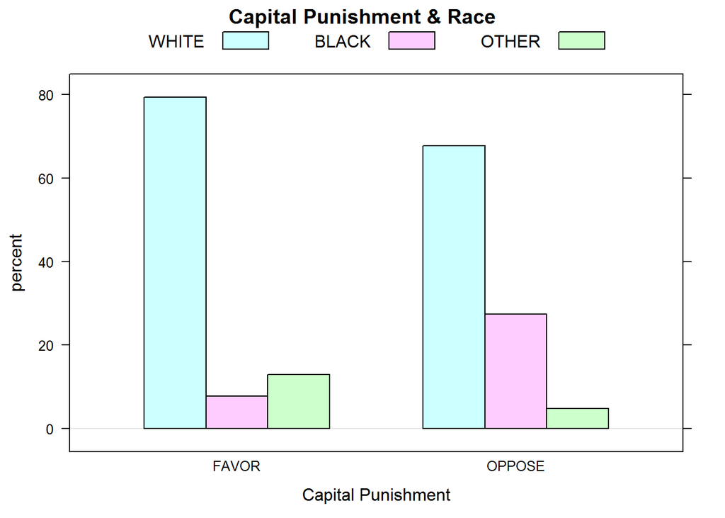

This chart shows us that among the white people the percent on both sides are about the same, for black people the ‘opposed’ side percentage is much higher than the ‘favored’ side, and for other race the ‘opposed’ side is quite lower than the ‘favored’ side. This shows us that there appears to be a relationship between a persons opinion on the death penalty and their race.

#### 3.2.1.2 Numerical Descriptive Results

```
##         RACE
## CAPPUN    WHITE  BLACK  OTHER  Total
##   FAVOR   79.31   7.76  12.93 100.00
##   OPPOSE  67.74  27.42   4.84 100.00
```

The numbers on this chart show us quite a difference for the three category races. White people appear to have a only a 12% difference. The number for black people nearly dropped 20% to opposing capital punishment. Finally for other race the percent differnce is 8%.

### 3.2.2 Inferential Results

```
## Pearson's Chi-squared test
##
## Observed Counts:
##         RACE
## CAPPUN   WHITE BLACK OTHER
##   FAVOR     92     9    15
##   OPPOSE    42    17     3
##
## Counts Expected by Null:
##         RACE
## CAPPUN   WHITE BLACK OTHER
##   FAVOR  87.33 16.94 11.73
##   OPPOSE 46.67  9.06  6.27
##
## Contributions to the chi-square statistic:
##         RACE
## CAPPUN   WHITE BLACK OTHER
##   FAVOR   0.25  3.72  0.91
##   OPPOSE  0.47  6.97  1.71
##
##
## Chi-Square Statistic = 14.0272
## Degrees of Freedom of the table = 2
## P-Value = 9e-04
```

# 4 Discussion and Conclusion

Question 1: The p-value for the Chisq test is 0.02 < 0.05 so we reject the null hypothesis and conclude we have evidence to support the contention that gun ownership and whether one favors capital punishment are related.

Question 2: The p-value 0.0801 > 0.05 so we fail to reject the null hypothesis and conclude we have no evidence to support that those in belief of the big bang theory and belief in the afterlife have a relationship.